# lab6YG

```r
library(dplyr)
library(ggplot2)
library(tidytext)
library(readr)
library(tidyr)
```

```r
mt_samples <- read_csv("https://raw.githubusercontent.com/USCbiostats/data-science-data/master/00_mtsamples/mtsamples.csv")
```

```
──────────────────────────────────────────────────────── Delimiter: "," chr
(5): description, medical_specialty, sample_name, transcription, keywords dbl
(1): ...1
```

```r
mt_samples <- mt_samples |>
  select(description, medical_specialty, transcription)

head(mt_samples)
```

```
# A tibble: 6 × 3
  description                                    medical_specialty transcription
  <chr>                                          <chr>             <chr>
1 A 23-year-old white female presents with comp… Allergy / Immuno… "SUBJECTIVE:…
2 Consult for laparoscopic gastric bypass.       Bariatrics        "PAST MEDICA…
3 Consult for laparoscopic gastric bypass.       Bariatrics        "HISTORY OF …
4 2-D M-Mode. Doppler.                           Cardiovascular /… "2-D M-MODE:…
5 2-D Echocardiogram                             Cardiovascular /… "1.  The lef…
6 Morbid obesity.  Laparoscopic antecolic anteg… Bariatrics        "PREOPERATIV…
```

#1:

```r
mt_samples %>%
  count(medical_specialty, sort = TRUE)
```

```
# A tibble: 40 × 2
   medical_specialty                 n
   <chr>                         <int>
 1 Surgery                        1103
 2 Consult - History and Phy.      516
 3 Cardiovascular / Pulmonary      372
 4 Orthopedic                      355
 5 Radiology                       273
 6 General Medicine                259
 7 Gastroenterology                230
 8 Neurology                       223
 9 SOAP / Chart / Progress Notes   166
10 Obstetrics / Gynecology         160
# ℹ 30 more rows
```

Ans: Not evenly distributed.

#2:

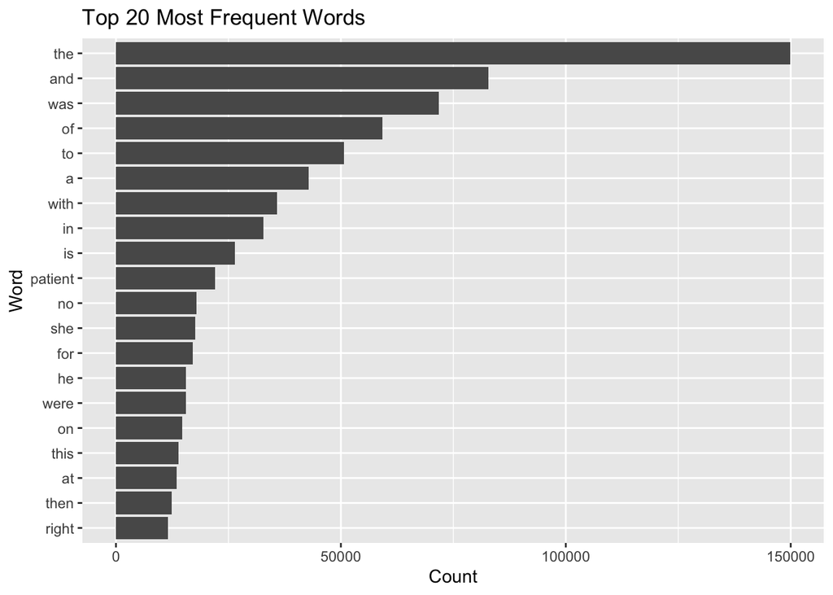

```r
mt_samples %>%
  unnest_tokens(word, transcription) %>%
  count(word, sort = TRUE) %>%
  top_n(20, n) %>%
  ggplot(aes(x = reorder(word, n), y=n)) +
  geom_col() +
  coord_flip() +
  labs(x = "Word", y = "Count", title="Top 20 Most Frequent Words")
```

Ans: Yes, this grapg makes sense bc the most frequent word is “the”, with a count close to 150,000. Other very frequent words are “and”, “was”, “of”, and “to”, each appearing tens of thousands of times. These are mostly common stopwords (articles, prepositions, pronouns). Examples: the, and, was, of, to, a, in, is. Some content-related words show up too, such as “patient”, which suggests the dataset may contain medical or clinical notes. Words at the bottom of the top-20 (e.g., then, right, at, this) still occur frequently but much less than the top words.

#3:

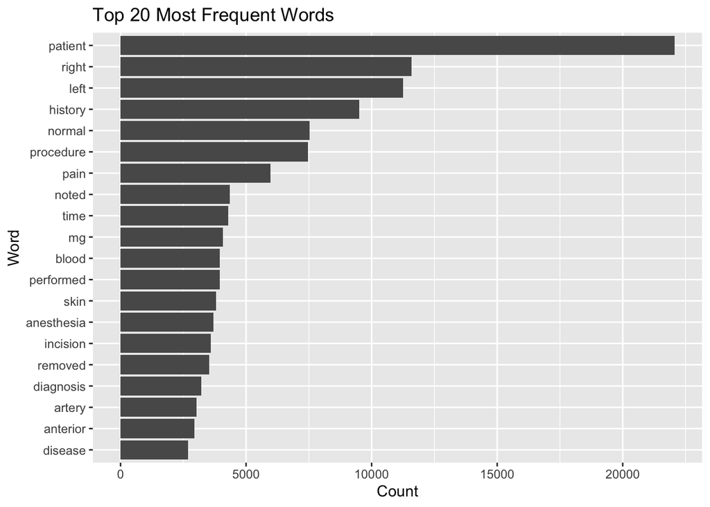

```r
mt_samples %>%
  unnest_tokens(word, transcription) %>%
  anti_join(stop_words %>% filter(!word %in% c("right", "left")), by = "word") %>%
  filter(!grepl("^[0-9]+$", word)) %>%
  count(word, sort = TRUE) %>%
  top_n(20, n) %>%
  ggplot(aes(x = reorder(word, n), y = n)) +
  geom_col() +
  coord_flip() +
  labs(x = "Word", y = "Count", title = "Top 20 Most Frequent Words")
```

Ans:

“patient” is far ahead of everything else. The presence of “right” and “left” being so high suggests a lot of laterality descriptions (right/left body parts, procedures).The vocabulary is clearly clinical — describing procedures, conditions, anatomy, and medical details. Compared to your earlier chart (dominated by stopwords like the, and, of), this one is much more domain-specific and useful for text analysis.

#4:

```r
mt_samples %>%
  unnest_tokens(bigram, transcription, token = "ngrams", n=2) %>%
  count(bigram, sort = TRUE) %>%
  top_n(20, n)
```

```
# A tibble: 20 × 2
   bigram          n
   <chr>       <int>
 1 the patient 20307
 2 of the      19062
 3 in the      12790
 4 to the      12374
 5 was then     6956
 6 and the      6350
 7 patient was  6293
 8 the right    5509
 9 on the       5241
10 the left     4860
11 with a       4857
12 history of   4537
13 to be        4345
14 is a         4014
15 with the     4002
16 there is     3950
17 at the       3657
18 there was    3334
19 patient is   3332
20 was placed   3328
```

```r
mt_samples %>%
  unnest_tokens(bigram, transcription, token = "ngrams", n=3) %>%
  count(bigram, sort = TRUE) %>%
  top_n(20, n)
```

```
# A tibble: 22 × 2
   bigram                 n
   <chr>              <int>
 1 the patient was     6104
 2 the patient is      3075
 3 as well as          2243
 4 there is no         1678
 5 the operating room  1532
 6 patient is a        1491
 7 prepped and draped  1490
 8 was used to         1480
 9 and draped in       1372
10 at this time        1333
# ℹ 12 more rows
```

#5:

```r
mt_samples %>%
  unnest_tokens(bigram, transcription, token = "ngrams", n=2) %>%
  separate(bigram, c("word1", "word2"), sep = " ") %>%
   filter(word1 == "patient" | word2 == "patient") %>%
  count(word1, word2, sort = TRUE)
```

```
# A tibble: 856 × 3
   word1   word2         n
   <chr>   <chr>     <int>
 1 the     patient   20307
 2 patient was        6293
 3 patient is         3332
 4 patient has        1417
 5 patient tolerated   994
 6 patient had         888
 7 patient will        616
 8 patient denies      552
 9 this    patient     470
10 patient and         377
# ℹ 846 more rows
```

#6:

```r
mt_samples %>%
  unnest_tokens(word, transcription) %>%
  anti_join(stop_words, by = "word") %>%
  filter(!grepl("^[0-9]+$", word)) %>%
  group_by(medical_specialty) %>%
  count(word, sort = TRUE) %>%
  top_n(5,n) %>%
  arrange(medical_specialty, desc(n))
```

```
# A tibble: 210 × 3
# Groups:   medical_specialty [40]
   medical_specialty    word          n
   <chr>                <chr>     <int>
 1 Allergy / Immunology history      38
 2 Allergy / Immunology noted        23
 3 Allergy / Immunology patient      22
 4 Allergy / Immunology allergies    21
 5 Allergy / Immunology nasal        13
 6 Allergy / Immunology past         13
 7 Autopsy              left         83
 8 Autopsy              inch         59
 9 Autopsy              neck         55
10 Autopsy              anterior     47
# ℹ 200 more rows
```

#7:

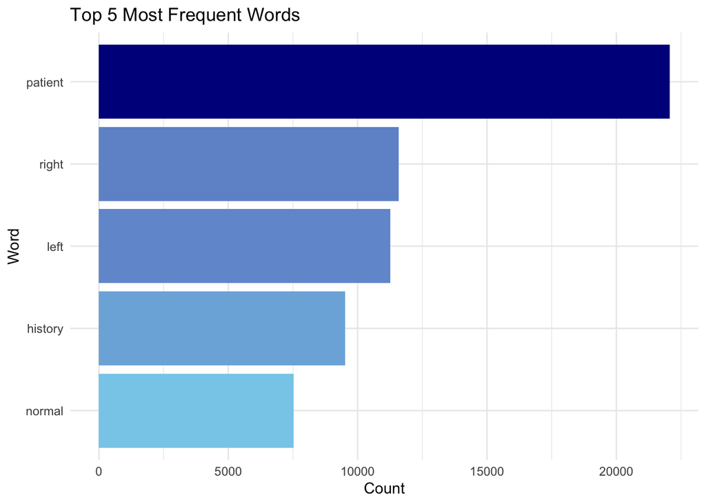

```r
mt_samples %>%
  unnest_tokens(word, transcription) %>%
  anti_join(stop_words %>% filter(!word %in% c("right", "left")), by = "word") %>%
  filter(!grepl("^[0-9]+$", word)) %>%
  count(word, sort = TRUE) %>%
  top_n(5, n) %>%
  ggplot(aes(x = reorder(word, n), y = n, fill = n)) +
  geom_col(show.legend = FALSE) +
  coord_flip() +
  scale_fill_gradient(low = "skyblue", high = "darkblue") +
  labs(x = "Word", y = "Count", title = "Top 5 Most Frequent Words") +
  theme_minimal()
```